# Constraints on the star formation histories of galaxies in the Local Cosmological Volume | Monthly Notices of the Royal Astronomical Society | Oxford Academic

[figure not shown]

[figure not shown]

[figure not shown]

Volume 497

Issue 1

September 2020

### Article Contents

Journal Article

# Constraints on the star formation histories of galaxies in the Local Cosmological Volume

P Kroupa, M Haslbauer, I Banik, S T Nagesh, J Pflamm-Altenburg

Author Notes

*Monthly Notices of the Royal Astronomical Society*, Volume 497, Issue 1, September 2020, Pages 37–43, https://doi.org/10.1093/mnras/staa1851

Published:

22 July 2020

Article history

## ABSTRACT

The majority of galaxies with current star formation rates (SFRs), , in the Local Cosmological Volume, where observations should be reliable, have the property that their observed SFR<sub>o</sub> is larger than their average SFR. This is in tension with the evolution of galaxies described by delayed-τ models, according to which the opposite would be expected. The tension is apparent in that local galaxies imply the star formation time-scale τ ≈ 6.7 Gyr, much longer than the 3.5–4.5 Gyr obtained using an empirically determined main sequence at several redshifts. Using models where the SFR is a power law in time of the form ∝(*t* − *t*<sub>1</sub>)<sup>η</sup> for *t*<sub>1</sub> = 1.8 Gyr (with no stars forming prior to *t*<sub>1</sub>) implies that η = 0.18 ± 0.03. This suggested near-constancy of a galaxy’s SFR over time raises non-trivial problems for the evolution and formation time of galaxies, but is broadly consistent with the observed decreasing main sequence with increasing age of the Universe.

Galaxy: evolution, Galaxy: formation, galaxies: evolution, galaxies: formation, galaxies: star formation, galaxies: stellar content

Issue Section:

Article

## 1 INTRODUCTION

The formation and evolution of observed galaxies constitutes a cosmological boundary condition that must be fulfilled by any physically realistic theory of cosmological structure formation and evolution. A Milky Way (MW)-type galaxy is generally thought to have begun forming ≈12 Gyr ago (i.e. at time *t*<sub>1</sub> ≈ 1.8 Gyr after the big bang, Planck Collaboration XIII 2016), reaching a maximum star formation rate (SFR)<sup>1</sup> with the SFR subsequently decreasing (e.g. Mor et al. 2019).

The MW is a well-studied case, for which measurements of the phase-space, chemical, and age parameters of a large ensemble of disc stars reveal a complex star formation history (SFH). It decreases from yr<sup>−1</sup> about 10 Gyr ago to a minimum with yr<sup>−1</sup> about Gyr ago, reaching a local maximum of yr<sup>−1</sup> about Gyr ago and decreasing to a present-day value of yr<sup>−1</sup> (Mor et al. 2019). While the data may also be interpreted with a constant yr<sup>−1</sup> over the past Gyr (yielding a present-day disc stellar mass of ), a general trend of a decreasing SFR has also been found by Zonoozi, Mahani & Kroupa (2019) based on the shape of the galaxy-wide stellar mass function, and from an analysis of the kinematical imprint of star formation in a clustered mode according to which the thick disc may have been formed from an elevated SFR about 10–12 Gyr ago (Kroupa 2002). Ruiz-Lara et al. (2020) map the SFH from >12 Gyr ago until today, finding consistency with the analysis by Mor et al. (2019) and showing time-resolved evidence that it may have been modulated over the past 6 Gyr by the orbit of the Sagittarius satellite galaxy.<sup>2</sup> In the context of Milgromian Dynamics (MOND; Milgrom 1983; Bekenstein & Milgrom 1984), the SFH of the MW is likely to have been significantly affected by its encounter with Andromeda (M31) about 7–10 Gyr ago (Zhao et al. 2013).<sup>3</sup> The MW SFH is thus not likely that of an unperturbed self-regulated secularly evolving disc galaxy. The other large galaxy in the Local Group, M31, had yr<sup>−1</sup> from 14 to 8 Gyr ago, with a dip to yr<sup>−1</sup> about 8–6 Gyr ago, a maximum near yr<sup>−1</sup> about 5–1.5 Gyr ago and a decline to yr<sup>−1</sup> or less (Williams et al. 2017, the quoted values comprise only the region of M31 mapped by the PHAT survey). It appears that the SFHs of the MW and M31 may be correlated, as the initial larger values, the minima and maxima appear to be broadly in-phase.

On the other hand, the Triangulum galaxy (M33) is a near-flocculent disc galaxy in the Local Group without a significant bulge and appears to have evolved largely without significant perturbations. Its SFR has increased significantly until the present time, with yr<sup>−1</sup>, while about 10 Gyr ago, yr<sup>−1</sup> with evidence for an acceleration and then minimum about 5 Gyr ago (Javadi et al. 2017). This SFH may be related to its orbit around M31 (Patel, Besla & Sohn 2017). The Large Magellanic Cloud (LMC) also shows an increasing SFR until today with a dip about 5 Gyr ago (Meschin et al. 2014). This SFH cannot be representative of an isolated self-regulated disc galaxy because the LMC is strongly interacting with the Small Magellanic Cloud and also with the MW. It may be noteworthy that all four major galaxies of the Local Group discussed above share a similar depression in their SFHs roughly Gyr ago. The evidence from the larger galaxies in the Local Group concerning the shapes of their SFHs is thus somewhat ambiguous and is mired by the Local Group members being subject to relatively strong encounters. The rather strikingly symmetrical arrangement of matter within the Local Group appears to be additionally troubling (Pawlowski et al. 2013).

(1)

Davé (2008) suggests this to be broadly consistent with dark-matter-based hydrodynamical simulations. Galaxy-formation simulations in Milgromian gravitation based on single-cloud collapse with negligible further gas accretion also lead to such a general behaviour, albeit with a much larger (Wittenburg, Kroupa & Famaey 2020).

In order to improve knowledge of galaxy formation and evolution, it is useful to also consider the ensemble of galaxies in the nearby Universe. Peebles & Nusser (2010) compare structure formation models to the spatial distribution of galaxies in the Local Cosmological Volume, defined by the sphere with radius Mpc, finding significant tension between the predicted and observed distribution of major galaxies. Here, the Catalogue of Neighbouring Galaxies (Section 2) is used to address if . In Section 3, it is shown that galaxies in the Local Cosmological Volume pose a challenge to this generally accepted understanding. Section 4 presents a discussion and the conclusions.

## 2 THE GALAXIES IN THE LOCAL COSMOLOGICAL VOLUME

The Catalogue of Neighbouring Galaxies (Karachentsev et al. 2004) and its update (Karachentsev, Makarov & Kaisina 2013) are used to extract the *K*-band luminosities and the SFRs based on integrated H α and far-ultraviolet (FUV) measurements for galaxies within a distance of ≈11 Mpc. The catalogue also lists limit flags on the FUV- and Hα-based SFR values. If a SFR value is marked with such a flag, it is excluded from the here presented analysis (but including flagged SFR values do not significantly affect the results). This gives a sample of 870 galaxies, from 1145. From these 870 galaxies, 267 have only far-ultraviolet (FUV)-based SFR values, 128 have only Hα based SFRs, and 475 have both measurements available. Thus, and galaxies lack FUV- and H α-based SFR measurements, respectively.<sup>6</sup> The *K*-band luminosity values are converted to *M** using a mass-to-light ratio of 0.6 (Lelli, McGaugh & Schombert 2016).

For galaxies which have both SFR measurements available, SFR<sub>o</sub> = (SFR<sub>FUV</sub> + SFR<sub>H α</sub>)/2 is adopted. Their SFRs based on integrated H α and FUV measurements are depicted in Fig. 1. The condition yr<sup>−1</sup> leaves 386 galaxies. For the galaxies which only have the FUV- or H α-based values, SFR<sub>o</sub> = SFR<sub>FUV</sub> or SFR<sub>o</sub> = SFR<sub>H α</sub>, respectively (these galaxies do not appear in Fig. 1). Applying the cut yr<sup>−1</sup> leaves 109 and 88 galaxies that have only SFR<sub>FUV</sub> or SFR<sub>H α</sub> data, respectively.

Figure 1.

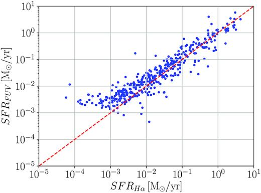

Comparison of the FUV- and H α-based SFR<sub>o</sub> values for those 386 galaxies in the Catalogue of Neighbouring Galaxies (Section 2) which have both measurements (and no limit flag on the SFR measurements) and for which also yr<sup>−1</sup>. The red dashed line is the 1:1 relation. The Catalogue of Neighbouring Galaxies does not provide uncertainties, but from the distance uncertainties (Karachentsev et al. 2004, 2013) it may be assumed that each measurement plotted here has a representative uncertainty of 30 per cent (not shown). Throughout the present analysis, the data are therefore treated with equal weights.

Galaxies with yr<sup>−1</sup> are not considered in the present analysis for the following four reasons (Karachentsev & Kaisina 2013 provide an in-depth discussion of these issues):

1. The SFR<sub>o</sub> values may be affected by a pronounced top-light galaxy-wide initial mass function (gwIMF) such that SFR<sub>o,H α</sub> < SFR<sub>o,FUV</sub>. Pflamm-Altenburg, Weidner & Kroupa (2009), Pflamm-Altenburg & Kroupa (2009), and section 4.3 in Jeřábková et al. (2018) provide a detailed discussion of this gwIMF behaviour, with the resolved dwarf galaxy DDO 154, which has a corresponding lack of massive stars, being a case in point (Watts et al. 2018). Indeed, the ratio SFR<sub>o,H α</sub>/SFR<sub>o,FUV</sub> is measured to decrease with decreasing SFR<sub>o,FUV</sub> or SFR<sub>o,H α</sub> (Lee et al. 2009), as predicted via the IGIMF theory<sup>7</sup> if the gwIMF becomes increasingly top-light with decreasing SFR (Pflamm-Altenburg et al. 2009), a trend observationally also suggested for more massive disc galaxies (Gunawardhana et al. 2011). This behaviour of the gwIMF with SFR would imply dwarf galaxies to be as efficient in forming stars as major disc galaxies (all having a gas depletion or consumption time-scale of about 3 Gyr), therewith explaining their ability to form their observed stellar populations within a Hubble time without the need to postulate that they have had much higher SFRs in the past (Pflamm-Altenburg et al. 2009). Also noteworthy in this context is that two well-studied galaxies, the ultra-diffuse Dragonfly 44 and the ultra-faint satellite Boötes I, had the same gas-depletion time as the above-mentioned star-forming dwarf galaxies as long as the analysis is performed self-consistently within the IGIMF theory (Haghi et al. 2019; Yan, Jerabkova & Kroupa 2020).
2. Related to the systematically changing gwIMF just discussed, it has been customary to describe star formation throughout a galaxy as being stochastic, an approach discussed in detail in Elmegreen (1997) and Elmegreen (1999).<sup>8</sup> Dwarf galaxies with low SFRs may lead to an undersampling of the gwIMF, but only if a central tenet of the IGIMF theory is adopted, namely that stars form in embedded clusters that dictate the available mass for the stellar population per cluster, leading to a difference in various SFR tracers (da Silva, Fumagalli & Krumholz 2014). Related to the suggestion that star formation is stochastic, Kennicutt & Evans (2012) discuss the possibility that dwarf galaxies may be prone to temporal variations of their SFRs. Applebaum et al. (2020) study the effect of a stochastic gwIMF on the formation and evolution of dwarf galaxies with cosmological simulations.
3. It is possible that the measured H α and UV fluxes are affected by photon leakage, dust obscuration, and redenning and other physical effects (Calzetti 2008, 2013). It is likely that these are relevant, but the authors of the research papers reporting evidence for systematic variations of the gwIMF in galaxies correct for these biases (Hoversten & Glazebrook 2008; Lee et al. 2009; Gunawardhana et al. 2011).
4. Many of the least massive galaxies in the Local Cosmological Volume with are satellite galaxies that stopped forming stars many Gyr ago (e.g. Grebel 1997; Grebel, Gallagher & Harbeck 2003). Dwarf galaxies sufficiently far from major galaxies of this mass behave as disc galaxies (e.g. the dwarf galaxy DDO 210 which is barely more massive than a massive globular cluster and which has a Milgromian rotation curve, putting it on the baryonic Tully–Fisher relation; Famaey & McGaugh 2012). Meanwhile, dwarf galaxies within the vicinity of major galaxies have lost their gas (Grebel et al. 2003).

Overall, dwarf and major star-forming galaxies thus appear to conform to the same basic physical evolution, although differences between the SFHs at the lowest mass end are evident and remain to be understood (Albers et al. 2019). Galaxies with yr<sup>−1</sup> are therefore considered to have too insecure SFRs and are thus omitted from the present analysis. For the in-total 583 galaxies used in this analysis, the gwIMF is near to canonical (Gunawardhana et al. 2011; Jeřábková et al. 2018).

In a companion paper (Haslbauer et al. in preparation), the Catalogue of Neighbouring Galaxies is compared with the SP14 main sequence. The (SFR<sub>o</sub>, *M**) values are in excellent agreement at , showing that the Catalogue of Neighbouring Galaxies conforms to the compilation by SP14.